# Multilayer Perceptron Models with the Kaggle Heart Disease Dataset

### MLPs

```python
model = Sequential()
model.add(Dense(2, input_dim=X.shape[1], activation='relu'))
model.add(Dense(1, activation='sigmoid'))
print(model.summary())
history = train_model(model, X_train, y_train, X_test, y_test)
```

```
Model: "sequential_11"
_________________________________________________________________
 Layer (type)                Output Shape              Param #
=================================================================
 dense_27 (Dense)            (None, 2)                 32

 dense_28 (Dense)            (None, 1)                 3

=================================================================
Total params: 35 (140.00 Byte)
Trainable params: 35 (140.00 Byte)
Non-trainable params: 0 (0.00 Byte)
_________________________________________________________________
None
Epoch 110: early stopping
```

```
Accuracy:  0.82
Specificity:  0.79
Recall:  0.86
F1 Score: 0.84
```

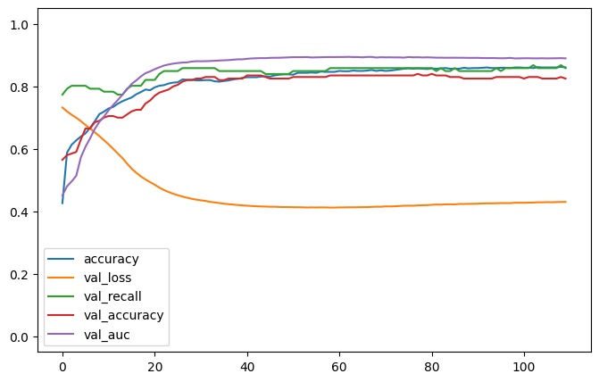

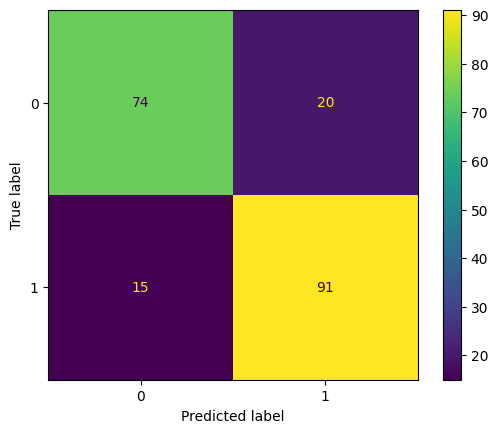

```python
evaluate_model(model, history, X_test, y_test)
```

```python
model = Sequential()
model.add(Dense(8, input_dim=X.shape[1], activation='relu'))
model.add(Dense(1, activation='sigmoid'))
print(model.summary())
history = train_model(model, X_train, y_train, X_test, y_test)
```

```
Model: "sequential_12"
_________________________________________________________________
 Layer (type)                Output Shape              Param #
=================================================================
 dense_29 (Dense)            (None, 8)                 128

 dense_30 (Dense)            (None, 1)                 9

=================================================================
Total params: 137 (548.00 Byte)
Trainable params: 137 (548.00 Byte)
Non-trainable params: 0 (0.00 Byte)
_________________________________________________________________
None
Epoch 85: early stopping
```

```
Accuracy:  0.84
Specificity:  0.81
Recall:  0.88
F1 Score: 0.86
```

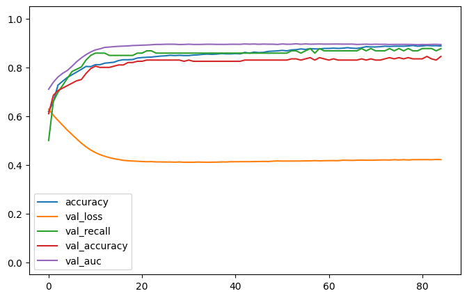

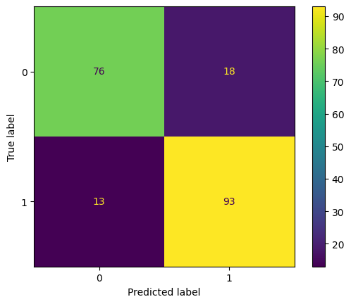

```python
evaluate_model(model, history, X_test, y_test)
```

```python
model = Sequential()
model.add(Dense(16, input_dim=X.shape[1], activation='relu'))
model.add(Dense(4, activation='relu'))
model.add(Dense(1, activation='sigmoid'))
print(model.summary())
history = train_model(model, X_train, y_train, X_test, y_test)
```

```
Model: "sequential_13"
_________________________________________________________________
 Layer (type)                Output Shape              Param #
=================================================================
 dense_31 (Dense)            (None, 16)                256

 dense_32 (Dense)            (None, 4)                 68

 dense_33 (Dense)            (None, 1)                 5

=================================================================
Total params: 329 (1.29 KB)
Trainable params: 329 (1.29 KB)
Non-trainable params: 0 (0.00 Byte)
_________________________________________________________________
None
Epoch 166: early stopping
```

```
Accuracy:  0.86
Specificity:  0.87
Recall:  0.85
F1 Score: 0.87
```

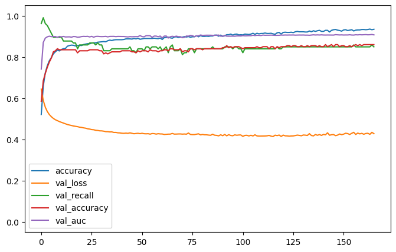

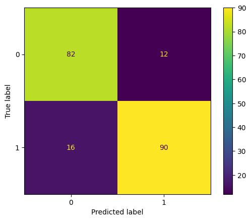

```python
evaluate_model(model, history, X_test, y_test)
```

```python
model = Sequential()
model.add(Dense(16, input_dim=X.shape[1], activation='relu'))
model.add(Dense(16, activation='relu'))
model.add(Dense(1, activation='sigmoid'))
print(model.summary())
history = train_model(model, X_train, y_train, X_test, y_test)
```

```
Model: "sequential_14"
_________________________________________________________________
 Layer (type)                Output Shape              Param #
=================================================================
 dense_34 (Dense)            (None, 16)                256

 dense_35 (Dense)            (None, 16)                272

 dense_36 (Dense)            (None, 1)                 17

=================================================================
Total params: 545 (2.13 KB)
Trainable params: 545 (2.13 KB)
Non-trainable params: 0 (0.00 Byte)
_________________________________________________________________
None
Epoch 72: early stopping
```

```
Accuracy:  0.83
Specificity:  0.81
Recall:  0.85
F1 Score: 0.84
```

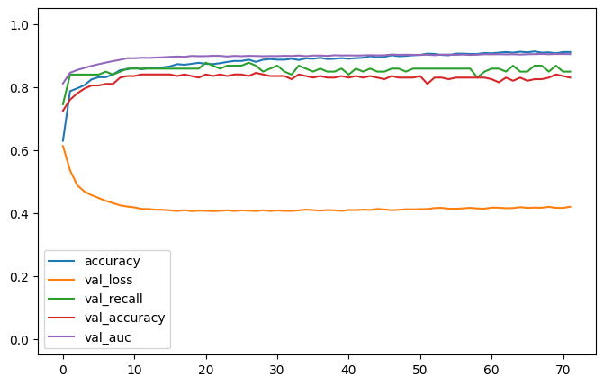

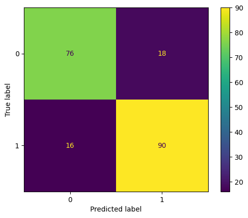

```python
evaluate_model(model, history, X_test, y_test)
```

```python
model = Sequential()
model.add(Dense(16, input_dim=X.shape[1], activation='relu'))
model.add(Dense(16, activation='relu'))
model.add(Dense(8, activation='relu'))
model.add(Dense(1, activation='sigmoid'))
print(model.summary())
history = train_model(model, X_train, y_train, X_test, y_test)
```

```
Model: "sequential_15"
_________________________________________________________________
 Layer (type)                Output Shape              Param #
=================================================================
 dense_37 (Dense)            (None, 16)                256

 dense_38 (Dense)            (None, 16)                272

 dense_39 (Dense)            (None, 8)                 136

 dense_40 (Dense)            (None, 1)                 9

=================================================================
Total params: 673 (2.63 KB)
Trainable params: 673 (2.63 KB)
Non-trainable params: 0 (0.00 Byte)
_________________________________________________________________
None
Epoch 101: early stopping
```

```
Accuracy:  0.82
Specificity:  0.79
Recall:  0.86
F1 Score: 0.84
```

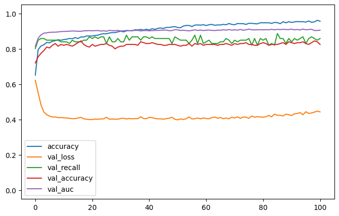

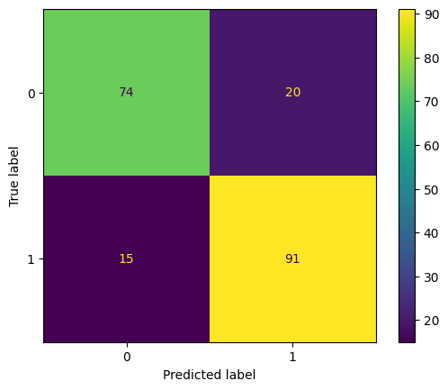

```python
evaluate_model(model, history, X_test, y_test)
```

```python
model = Sequential()
model.add(Dense(16, input_dim=X.shape[1], activation='relu'))
model.add(Dense(16, activation='relu'))
model.add(Dense(12, activation='relu'))
model.add(Dense(1, activation='sigmoid'))
print(model.summary())
history = train_model(model, X_train, y_train, X_test, y_test)
```

```
Model: "sequential_16"
_________________________________________________________________
 Layer (type)                Output Shape              Param #
=================================================================
 dense_41 (Dense)            (None, 16)                256

 dense_42 (Dense)            (None, 16)                272

 dense_43 (Dense)            (None, 12)                204

 dense_44 (Dense)            (None, 1)                 13

=================================================================
Total params: 745 (2.91 KB)
Trainable params: 745 (2.91 KB)
Non-trainable params: 0 (0.00 Byte)
_________________________________________________________________
None
Epoch 79: early stopping
```

```
Accuracy:  0.88
Specificity:  0.85
Recall:  0.91
F1 Score: 0.89
```

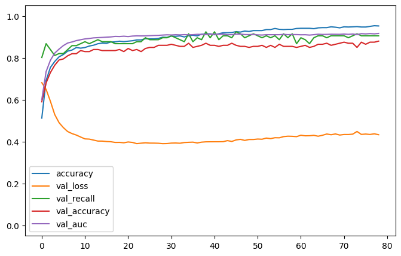

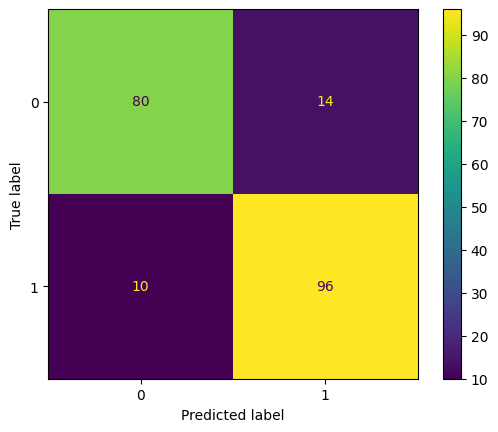

```python
evaluate_model(model, history, X_test, y_test)
```

```python
model_f = Sequential()
model_f.add(Dense(16, input_dim=X.shape[1], activation='relu'))
model_f.add(Dense(16, activation='relu'))
model_f.add(Dense(12, activation='relu'))
model_f.add(Dense(12, activation='relu'))
model_f.add(Dense(1, activation='sigmoid'))
print(model.summary())
history_f = train_model(model_f, X_train, y_train, X_test, y_test)
```

```
Model: "sequential_16"
_________________________________________________________________
 Layer (type)                Output Shape              Param #
=================================================================
 dense_41 (Dense)            (None, 16)                256

 dense_42 (Dense)            (None, 16)                272

 dense_43 (Dense)            (None, 12)                204

 dense_44 (Dense)            (None, 1)                 13

=================================================================
Total params: 745 (2.91 KB)
Trainable params: 745 (2.91 KB)
Non-trainable params: 0 (0.00 Byte)
_________________________________________________________________
None
Epoch 78: early stopping
```

```
Accuracy:  0.88
Specificity:  0.85
Recall:  0.91
F1 Score: 0.89
```

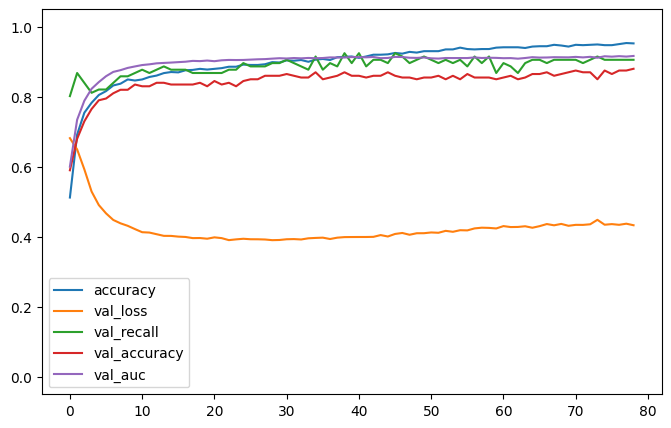

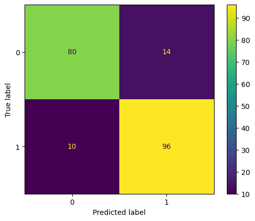

```python
evaluate_model(model, history, X_test, y_test)
```

### What architecture (how big) you do need to overfit when you have output as additional input feature?

Below we use the output from our best model and iteratively train a model with the previous model's output. The below architecture is the "slimmest" we could find that would perfectly classify the training set.

```python
train_pred = model_f.predict(X_train)
test_pred = model_f.predict(X_test)
```

```python
X_train_grad =X_train.copy()
X_train_grad["preds"] = train_pred

X_test_grad = X_test.copy()
X_test_grad["preds"] = test_pred

accs = []
Epoch = 1
Go = True


while Go:
    model_g = Sequential()
    model_g.add(Dense(9, input_dim = X_train_grad.shape[1], activation='relu'))
    model_g.add(Dense(1, activation='sigmoid'))
    history = train_model(model_g, X_train_grad, y_train, X_train_grad, y_train)
    X_train_grad["preds"] = model_g.predict(X_train_grad)
    X_test_grad["preds"] = model_g.predict(X_test_grad)

    _acc = accuracy_score(y_train, (X_train_grad["preds"]>0.5)*1)
    accs.append(_acc)
    print(f"Epoch {Epoch}: {_acc: 0.4f}")
    if _acc > 0.999:
        Go = False
    Epoch += 1
```

```
Epoch 1:  0.9828
Epoch 2:  0.9929
Epoch 3:  0.9990
Epoch 4:  1.0000
```

```
Accuracy:  0.85
Specificity:  0.83
Recall:  0.87
F1 Score: 0.86
```

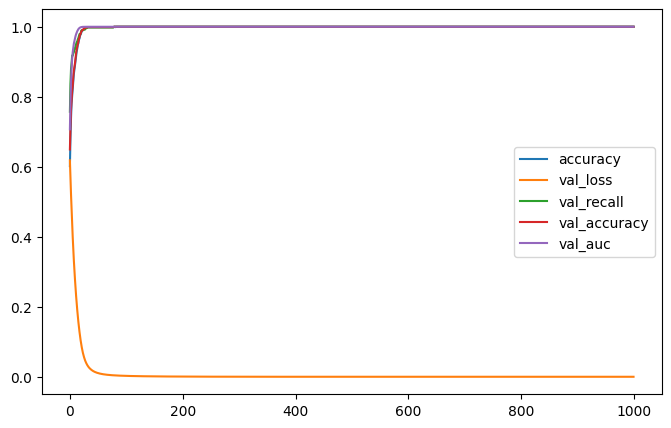

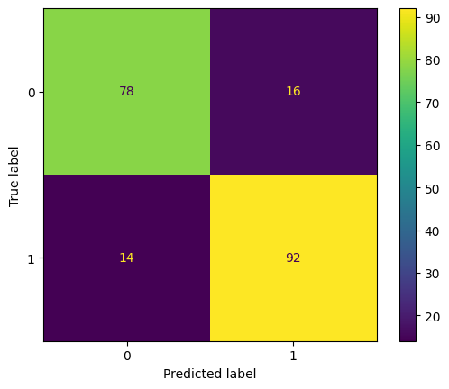

```python
evaluate_model(model_g, history, X_test_grad, y_test)
```

Below is the minimum architecture needed using output as input in order to achieve 100% in-sample accuracy.

```python
print(model_g.summary())
```

```
Model: "sequential_21"
_________________________________________________________________
 Layer (type)                Output Shape              Param #
=================================================================
 dense_56 (Dense)            (None, 9)                 153

 dense_57 (Dense)            (None, 1)                 10

=================================================================
Total params: 163 (652.00 Byte)
Trainable params: 163 (652.00 Byte)
Non-trainable params: 0 (0.00 Byte)
_________________________________________________________________
None
```

## Phase 4: Feature Importance and Reduction

The key activity in this phase is to study the importance of the input features by iteratively removing them. You must continue to use model checkpointing in this phase. Here are the steps involved:

- If you have 10 input features/columns, train 10 models where each model only receives one feature at a time.
  - For example, if age, BMI, and blood pressure are your only three input features, you train three models: one that only take age as input, another that only takes BMI as the input, and the last one that takes only blood pressure as the input.
  - The validation accuracy of these three models will indicate the relative importance of the three features.
  - You should plot these validation accuracies in the form of a bar diagram. If all your accuracies are more than 80%, your plot’s y-axis should be limited to 80-100.
- From the previous step you have the significance/important of each feature. The feature that yields the highest accuray is the most important feature.
  - Starting with the most unimportant feature, remove one feature at a time (without replacement) and train various models.
  - You can iteratively repeat the process removing more and more unimportant features. For example, if BMI is the most important feature and blood pressure is the least important one, you would train two models: one without blood pressure, and one without blood pressure and age.
  - Plot the validation dataset accuracy of all the models that you tested. The overall objective is to identify non-informative input features and remove them from the dataset.
- Finally, you can compare your feature-reduced model with the original model with all input features and discuss the difference in accuracy.

For bonus points: Use model-agnostic methods such as LIME or Shapley values to derive feature importance.

https://christophm.github.io/interpretable-ml-book/

```python
def create_model():
    model = Sequential()
    model.add(Dense(1, input_dim=1, activation='sigmoid'))
    return model
```

```python
feature_models = []
for i in range(X_train.shape[1]):
    feature_models.append((create_model(), X_train.iloc[:, i], y_train,  X_test.iloc[:, i], y_test))
```

```python
from funcs import mp_train
```

```python
pool = multiprocessing.Pool()
history = pool.starmap(mp_train, feature_models)
pool.close()
pool.join()
```

```python
def f_acc(idx, model_list, _X, _y):
    _preds = model_list[idx][0].predict(_X.iloc[:,idx])
    _y_preds_01 = (_preds >= 0.5)*1
    return accuracy_score(_y_preds_01, _y)
```

```python
feature_scores = {}
cols = X_train.columns
for i in range(X_train.shape[1]):
    feature_scores[cols[i]] = f_acc(i, feature_models, X_test, y_test)
```

```python
feature_scores = dict(sorted(feature_scores.items(), key=lambda item: item[1]))
```

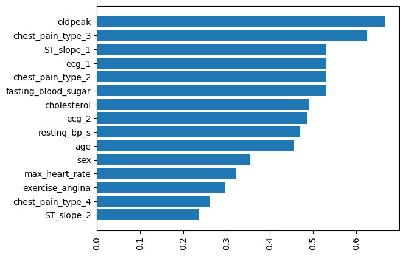

```python
plt.barh(*zip(*feature_scores.items()))
plt.xticks(rotation=90)
plt.show()
```

```python
feature_scores
```

```
{'ST_slope_2': 0.235,
 'chest_pain_type_4': 0.26,
 'exercise_angina': 0.295,
 'max_heart_rate': 0.32,
 'sex': 0.355,
 'age': 0.455,
 'resting_bp_s': 0.47,
 'ecg_2': 0.485,
 'cholesterol': 0.49,
 'fasting_blood_sugar': 0.53,
 'chest_pain_type_2': 0.53,
 'ecg_1': 0.53,
 'ST_slope_1': 0.53,
 'chest_pain_type_3': 0.625,
 'oldpeak': 0.665}
```

```python
# https://towardsdatascience.com/using-shap-values-to-explain-how-your-machine-learning-model-works-732b3f40e137
# Fits the explainer
np.random.seed(2112)
explainer = shap.Explainer(model_f.predict, X_test)
# Calculates the SHAP values - It takes some time
shap_values = explainer(X_test, silent=True)
```

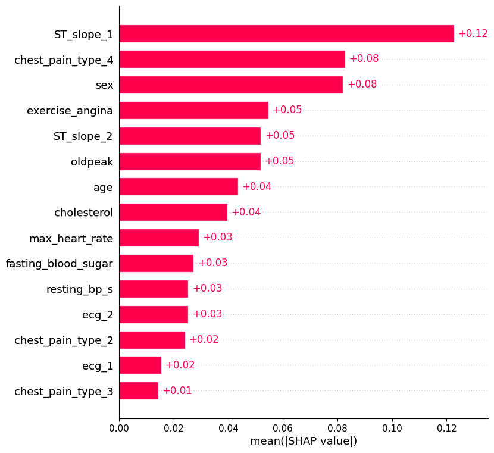

```python
shap.plots.bar(shap_values, max_display=1000)
```

```
Epoch 98: early stopping
Model: "sequential_16"
_________________________________________________________________
 Layer (type)                Output Shape              Param #
=================================================================
 dense_41 (Dense)            (None, 16)                256

 dense_42 (Dense)            (None, 16)                272

 dense_43 (Dense)            (None, 12)                204

 dense_44 (Dense)            (None, 1)                 13

=================================================================
Total params: 745 (2.91 KB)
Trainable params: 745 (2.91 KB)
Non-trainable params: 0 (0.00 Byte)
_________________________________________________________________
None
Included features: ['resting_bp_s', 'ecg_2', 'fasting_blood_sugar', 'age', 'max_heart_rate', 'chest_pain_type_2', 'cholesterol', 'exercise_angina', 'chest_pain_type_3', 'oldpeak', 'chest_pain_type_4', 'ST_slope_1', 'ST_slope_2', 'sex']
Accuracy:  0.86
Specificity:  0.88
Recall:  0.84
F1 Score: 0.86
```

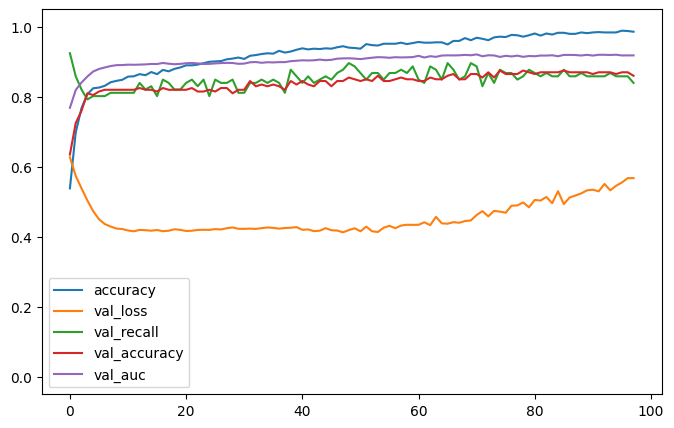

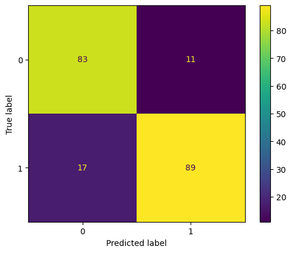

```
Epoch 62: early stopping
Model: "sequential_16"
_________________________________________________________________
 Layer (type)                Output Shape              Param #
=================================================================
 dense_41 (Dense)            (None, 16)                256

 dense_42 (Dense)            (None, 16)                272

 dense_43 (Dense)            (None, 12)                204

 dense_44 (Dense)            (None, 1)                 13

=================================================================
Total params: 745 (2.91 KB)
Trainable params: 745 (2.91 KB)
Non-trainable params: 0 (0.00 Byte)
_________________________________________________________________
None
Included features: ['ecg_2', 'fasting_blood_sugar', 'age', 'max_heart_rate', 'chest_pain_type_2', 'cholesterol', 'exercise_angina', 'chest_pain_type_3', 'oldpeak', 'chest_pain_type_4', 'ST_slope_1', 'ST_slope_2', 'sex']
Accuracy:  0.83
Specificity:  0.79
Recall:  0.87
F1 Score: 0.84
```

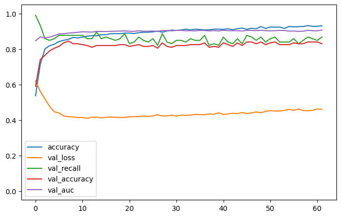

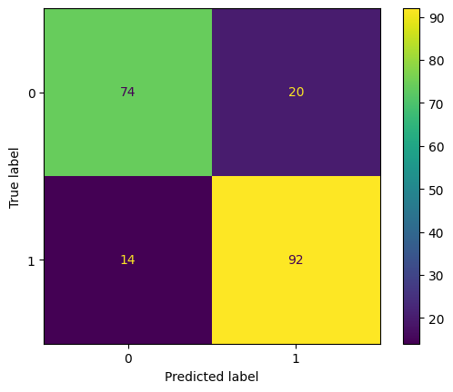

```
Epoch 62: early stopping
Model: "sequential_16"
_________________________________________________________________
 Layer (type)                Output Shape              Param #
=================================================================
 dense_41 (Dense)            (None, 16)                256

 dense_42 (Dense)            (None, 16)                272

 dense_43 (Dense)            (None, 12)                204

 dense_44 (Dense)            (None, 1)                 13

=================================================================
Total params: 745 (2.91 KB)
Trainable params: 745 (2.91 KB)
Non-trainable params: 0 (0.00 Byte)
_________________________________________________________________
None
Included features: ['fasting_blood_sugar', 'age', 'max_heart_rate', 'chest_pain_type_2', 'cholesterol', 'exercise_angina', 'chest_pain_type_3', 'oldpeak', 'chest_pain_type_4', 'ST_slope_1', 'ST_slope_2', 'sex']
Accuracy:  0.83
Specificity:  0.8
Recall:  0.87
F1 Score: 0.85
```

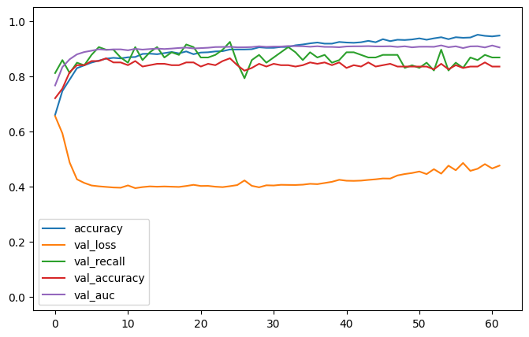

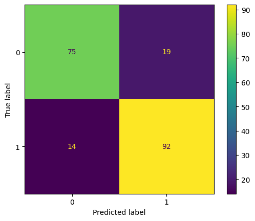

```
Epoch 120: early stopping
Model: "sequential_16"
_________________________________________________________________
 Layer (type)                Output Shape              Param #
=================================================================
 dense_41 (Dense)            (None, 16)                256

 dense_42 (Dense)            (None, 16)                272

 dense_43 (Dense)            (None, 12)                204

 dense_44 (Dense)            (None, 1)                 13

=================================================================
Total params: 745 (2.91 KB)
Trainable params: 745 (2.91 KB)
Non-trainable params: 0 (0.00 Byte)
_________________________________________________________________
None
Included features: ['age', 'max_heart_rate', 'chest_pain_type_2', 'cholesterol', 'exercise_angina', 'chest_pain_type_3', 'oldpeak', 'chest_pain_type_4', 'ST_slope_1', 'ST_slope_2', 'sex']
Accuracy:  0.85
Specificity:  0.79
Recall:  0.91
F1 Score: 0.86
```

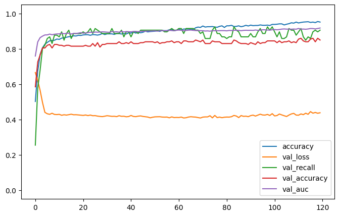

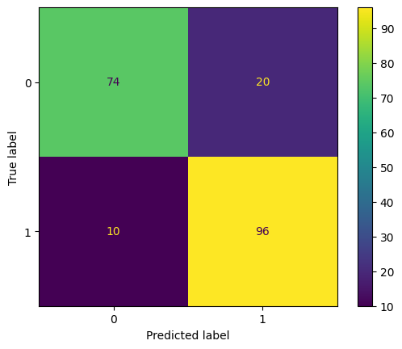

```
Epoch 83: early stopping
Model: "sequential_16"
_________________________________________________________________
 Layer (type)                Output Shape              Param #
=================================================================
 dense_41 (Dense)            (None, 16)                256

 dense_42 (Dense)            (None, 16)                272

 dense_43 (Dense)            (None, 12)                204

 dense_44 (Dense)            (None, 1)                 13

=================================================================
Total params: 745 (2.91 KB)
Trainable params: 745 (2.91 KB)
Non-trainable params: 0 (0.00 Byte)
_________________________________________________________________
None
Included features: ['max_heart_rate', 'chest_pain_type_2', 'cholesterol', 'exercise_angina', 'chest_pain_type_3', 'oldpeak', 'chest_pain_type_4', 'ST_slope_1', 'ST_slope_2', 'sex']
Accuracy:  0.85
Specificity:  0.85
Recall:  0.86
F1 Score: 0.86
```

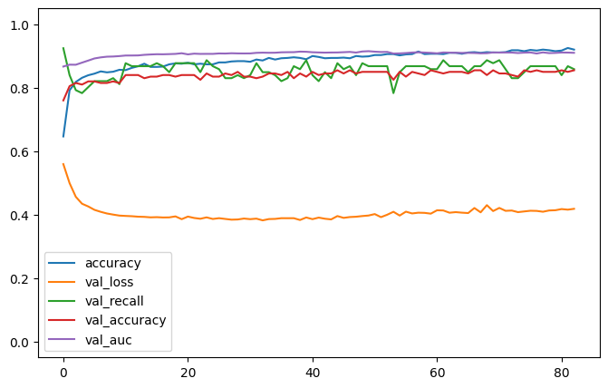

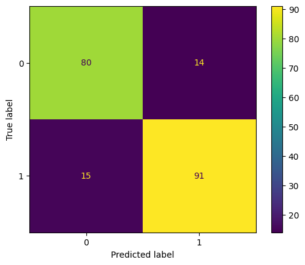

```
Epoch 92: early stopping
Model: "sequential_16"
_________________________________________________________________
 Layer (type)                Output Shape              Param #
=================================================================
 dense_41 (Dense)            (None, 16)                256

 dense_42 (Dense)            (None, 16)                272

 dense_43 (Dense)            (None, 12)                204

 dense_44 (Dense)            (None, 1)                 13

=================================================================
Total params: 745 (2.91 KB)
Trainable params: 745 (2.91 KB)
Non-trainable params: 0 (0.00 Byte)
_________________________________________________________________
None
Included features: ['chest_pain_type_2', 'cholesterol', 'exercise_angina', 'chest_pain_type_3', 'oldpeak', 'chest_pain_type_4', 'ST_slope_1', 'ST_slope_2', 'sex']
Accuracy:  0.84
Specificity:  0.81
Recall:  0.87
F1 Score: 0.85
```

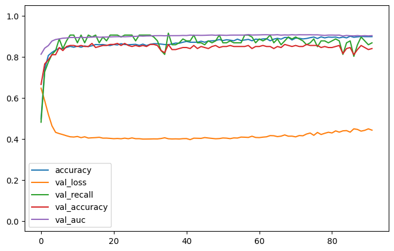

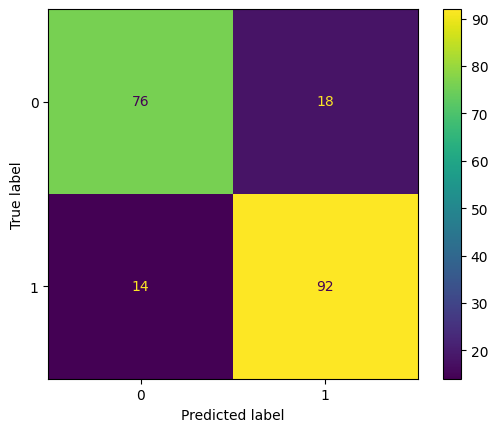

```
Epoch 138: early stopping
Model: "sequential_16"
_________________________________________________________________
 Layer (type)                Output Shape              Param #
=================================================================
 dense_41 (Dense)            (None, 16)                256

 dense_42 (Dense)            (None, 16)                272

 dense_43 (Dense)            (None, 12)                204

 dense_44 (Dense)            (None, 1)                 13

=================================================================
Total params: 745 (2.91 KB)
Trainable params: 745 (2.91 KB)
Non-trainable params: 0 (0.00 Byte)
_________________________________________________________________
None
Included features: ['cholesterol', 'exercise_angina', 'chest_pain_type_3', 'oldpeak', 'chest_pain_type_4', 'ST_slope_1', 'ST_slope_2', 'sex']
Accuracy:  0.84
Specificity:  0.82
Recall:  0.86
F1 Score: 0.85
```

[16 more figures not shown]

```python
feature_rank = ["ecg_1", "resting_bp_s", "ecg_2",
                    "fasting_blood_sugar", "age", "max_heart_rate",
                    "chest_pain_type_2", "cholesterol", "exercise_angina",
                    "chest_pain_type_3", "oldpeak", "chest_pain_type_4",
                    "ST_slope_1", "ST_slope_2", "sex"]

removed_features = []
for i in range(X_train.shape[1]-1):
    feature_rank.pop(0)
    model_s = Sequential()
    model_s.add(Dense(16, input_dim=len(feature_rank), activation='relu'))
    model_s.add(Dense(16, activation='relu'))
    model_s.add(Dense(12, activation='relu'))
    model_s.add(Dense(12, activation='relu'))
    model_s.add(Dense(1, activation='sigmoid'))
    history_s = train_model(model_s, X_train.loc[:,feature_rank], y_train, X_test.loc[:,feature_rank], y_test)
    print(model.summary())
    print(f"Included features: {feature_rank}")
    evaluate_model(model_s, history_s, X_test.loc[:,feature_rank], y_test)
```

## Phase 5: Final Report

- Please submit a PDF of your final report.
- 10/12 pages at most.
- Should include abstract and conclusion (each 250 words minimum).
- It should contain the important findings in each phase of your project.
- Your final/best model should be evaulated using ROC and AUC
- Your report should NOT include the results of your Phase II.
- Your tables and figures should be numbered and captioned (labelled) appropriately.
- Submit a link to your final Notebook. Optionally, you are welcome to host your project (and report) at Github (i.e., no extra points for hosting). .